# Linear Algebra for Data Science

## Part 1B. Vectors and Basic Operations

In this notebook, we will cover:

1. **What is a vector?** (Basic definitions, geometric intuition)
2. **Scalar vs. Vector vs. Matrix** (Differences and typical uses)
3. **Common vector operations**:
   - Addition and subtraction
   - Scalar multiplication
   - Dot product (including geometric interpretation: angle, projection)

```python
# If needed, install libraries (uncomment if running in a fresh environment like Google Colab)
# !pip install numpy matplotlib

import numpy as np
import matplotlib.pyplot as plt
```

## 1. What is a Vector?

A **vector** is a mathematical object that can be:

- **Geometrically** interpreted as an arrow in space (e.g., 2D plane, 3D space).
- **Algebraically** represented as an ordered list of numbers (called components).

```python
# Creating a 2D vector and a 3D vector
v2 = np.array([3, 4])
v3 = np.array([1, 2, 3])

print("2D vector:", v2, "Shape:", v2.shape)
print("3D vector:", v3, "Shape:", v3.shape)

# Note: np.array([3,4]) is basically 1-dimensional in Python with length 2.
```

```
2D vector: [3 4] Shape: (2,)
3D vector: [1 2 3] Shape: (3,)
```

### 1.1 Geometric Interpretation

- In 2D, a vector could look like an arrow drawn from the origin (0,0) to a point (x, y).
- In 3D, it would be an arrow from (0,0,0) to (x, y, z).
- You can visualize it as describing both **magnitude** (length) and **direction**.

### 1.2 Algebraic Representation

A vector can be written as a column of numbers (most common in math) or a row of numbers in many programming contexts. For instance, a 2D vector might be:

$$\begin{pmatrix} x \\ y \end{pmatrix}\quad \text{or simply as an array } [x, \, y].$$

### 1.3 Notation & Dimensions

- A vector in $\mathbb{R}^n$ is an ordered list of $n$ real numbers.
- Example in 3D: $\mathbf{v} = (v_1, v_2, v_3)$.
- The **dimension** of the vector is the number of components it has.

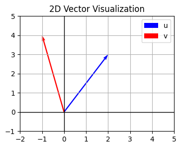

```python
# Let's visualize two 2D vectors for illustration
origin = np.array([0, 0])  # origin point

u = np.array([2, 3])
v = np.array([-1, 4])

plt.figure(figsize=(4, 3))

# Plot vector u in blue
plt.quiver(*origin, *u, angles='xy', scale_units='xy', scale=1, color='blue', label='u')

# Plot vector v in red
plt.quiver(*origin, *v, angles='xy', scale_units='xy', scale=1, color='red', label='v')

# Setting the axes
plt.xlim(-2, 5)
plt.ylim(-1, 5)
plt.axhline(0, color='black', linewidth=1)
plt.axvline(0, color='black', linewidth=1)

plt.grid()
plt.legend()
plt.title("2D Vector Visualization")
plt.show()
```

## 2. Scalar vs. Vector vs. Matrix

- **Scalar**: A single number (e.g., 7, 3.14). In Python, just a float or int.
- **Vector**: A 1D array of numbers (e.g., [3, 5, 2]).
- **Matrix**: A 2D grid of numbers (e.g., a table of shape $m \times n$).

[figure not shown]

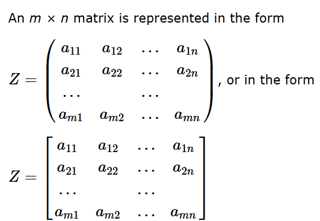

### Typical Uses in Data Science

- **Scalars**: learning rate in gradient descent, a single measurement, etc.
- **Vectors**: a data point with multiple features, model parameters in linear regression.
- **Matrices**: entire datasets (rows = samples, columns = features), weight matrices in neural networks.

[figure not shown]

## 3. Common Vector Operations

Let's look at the most important operations you'll do with vectors.

### 3.1 Vector Addition and Subtraction

- **Addition**: If $\mathbf{u} = (u_1, u_2, ..., u_n)$ and $\mathbf{v} = (v_1, v_2, ..., v_n)$, then $$\mathbf{u} + \mathbf{v} = (u_1 + v_1, \, u_2 + v_2, \, ..., u_n + v_n).$$
- **Subtraction**: $\mathbf{u} - \mathbf{v} = (u_1 - v_1, \, u_2 - v_2, \, ..., u_n - v_n).$

```python
u = np.array([1, 2, 4])
v = np.array([3, 5, 2])

# Addition
add_uv = u + v
print("u + v =", add_uv)
```

```
u + v = [4 7 6]
```

```python
# Subtraction
sub_uv = u - v
print("u - v =", sub_uv)
```

```
u - v = [-2 -3  2]
```

Geometrically, this corresponds to placing the **tail** of $\mathbf{v}$ at the **head** of $\mathbf{u}$ and drawing the diagonal of the parallelogram formed.

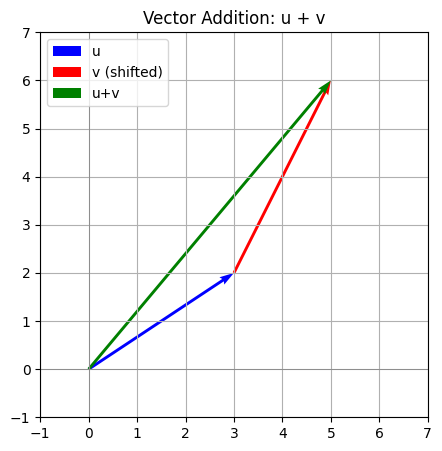

```python
# Let's define two 2D vectors u and v
u = np.array([3, 2])
v = np.array([2, 4])

# For convenience in plotting arrows from the origin, we'll define:
origin = np.array([0, 0])  # coordinate (0,0)

# Vector addition
u_plus_v = u + v

plt.figure(figsize=(5,5))

# Plot vector u (blue)
plt.quiver(*origin, *u, color='blue', angles='xy', scale_units='xy', scale=1, label='u')

# Plot vector v from the HEAD of u (so the tail is at u)
# To do this, we shift the origin to u
plt.quiver(*u, *(v), color='red', angles='xy', scale_units='xy', scale=1, label='v (shifted)')

# Plot the resultant (u+v) from the origin
plt.quiver(*origin, *u_plus_v, color='green', angles='xy', scale_units='xy', scale=1, label='u+v')

# Formatting the axes
plt.xlim(-1, 7)
plt.ylim(-1, 7)
plt.axhline(0, color='grey', linewidth=0.5)
plt.axvline(0, color='grey', linewidth=0.5)
plt.grid()
plt.title("Vector Addition: u + v")
plt.legend(loc=2)
plt.show()
```

**Notes**:

- The **blue** arrow is $\mathbf{u}$.
- The **red** arrow starts at the tip of $\mathbf{u}$ and represents $\mathbf{v}$.
- The **green** arrow is the resultant $\mathbf{u} + \mathbf{v}$ starting from the origin.

#### Visualizing Vector Subtraction

**Concept**: $\mathbf{u} - \mathbf{v}$ is the same as $\mathbf{u} + (-\mathbf{v})$. Geometrically, you can think of reversing $\mathbf{v}$ and then doing an addition.

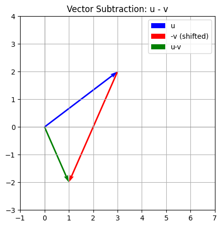

```python
# Vector subtraction
u_minus_v = u - v

plt.figure(figsize=(5,5))

# Plot u (blue)
plt.quiver(*origin, *u, color='blue', angles='xy', scale_units='xy', scale=1, label='u')

# Plot -v (the opposite of v) from the HEAD of u
neg_v = -v
plt.quiver(*u, *neg_v, color='red', angles='xy', scale_units='xy', scale=1, label='-v (shifted)')

# Plot the resultant (u-v) from origin
plt.quiver(*origin, *u_minus_v, color='green', angles='xy', scale_units='xy', scale=1, label='u-v')

# Formatting
plt.xlim(-1, 7)
plt.ylim(-3, 4)
plt.axhline(0, color='grey', linewidth=0.5)
plt.axvline(0, color='grey', linewidth=0.5)
plt.grid()
plt.title("Vector Subtraction: u - v")
plt.legend()
plt.show()
```

**Notes**:

- The **red** arrow is $-\mathbf{v}$, placed at the tip of $\mathbf{u}$.
- The **green** arrow shows $\mathbf{u} - \mathbf{v}$ from the origin.

### 3.2 Scalar Multiplication

- If $c$ is a scalar and $\mathbf{v} = (v_1, v_2, ..., v_n)$, then: $$c \mathbf{v} = (c \cdot v_1, \, c \cdot v_2, \, ..., c \cdot v_n).$$
- Geometrically, scalar multiplication **stretches** (if $|c|>1$) or **shrinks** (if $|c|<1$) the vector length, and if $c < 0$, it flips the direction.

```python
# Scalar Multiplication

scalar_mult = 2 * u
print("2 * u =", scalar_mult)
```

```
2 * u = [6 4]
```

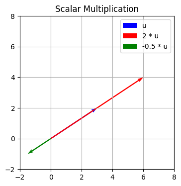

```python
# Let's do a couple of scalars
c1 = 2
c2 = -0.5

plt.figure(figsize=(4,4))

# Plot original u
plt.quiver(*origin, *u, color='blue', angles='xy', scale_units='xy', scale=1, lw= 2, label='u')

# Plot c1 * u
plt.quiver(*origin, *(c1*u), color='red', angles='xy', scale_units='xy', scale=1,
           label='2 * u')

# Plot c2 * u
plt.quiver(*origin, *(c2*u), color='green', angles='xy', scale_units='xy', scale=1,
           label='-0.5 * u')

# Formatting
plt.xlim(-2, 8)
plt.ylim(-2, 8)
plt.axhline(0, color='k', linewidth=0.5)
plt.axvline(0, color='k', linewidth=0.5)
plt.grid()
plt.title("Scalar Multiplication")
plt.legend()
plt.show()
```

### 3.3 Dot Product

- The **dot product** of two vectors $\mathbf{u}$ and $\mathbf{v}$ (of the same dimension) is defined as: $$\mathbf{u} \cdot \mathbf{v} = \sum_{i=1}^{n} u_i \, v_i.$$ In 2D, that looks like: $$(u_1, u_2) \cdot (v_1, v_2) = u_1 v_1 + u_2 v_2.$$
- **Geometric Interpretation**: $$\mathbf{u} \cdot \mathbf{v} = \|\mathbf{u}\| \|\mathbf{v}\| \cos(\theta),$$ where $\theta$ is the angle between the two vectors, and $\|\mathbf{u}\|$ is the magnitude (length) of $\mathbf{u}$.
  - If the dot product is **positive**: vectors point more or less in the **same** direction (angle < 90°).
  - If the dot product is **zero**: vectors are **perpendicular** (angle = 90°).
  - If the dot product is **negative**: vectors point more or less in **opposite** directions (angle > 90°).
- **Projection**: The dot product can be used to project one vector onto another: $$\text{proj}_{\mathbf{v}}(\mathbf{u}) = \left(\frac{\mathbf{u} \cdot \mathbf{v}}{\|\mathbf{v}\|^2}\right) \mathbf{v}.$$

### Geometric Interpretation of Dot Product

```python
u = np.array([2, 3])
v = np.array([4, 1])

dot_value = np.dot(u, v)
print("Dot product (u.v) =", dot_value)
```

```
Dot product (u.v) = 11
```

```python
# Element-wise multiplication
u * v
```

```
array([8, 3])
```

```python
# Let's compute the angle between u and v
u_norm = np.linalg.norm(u)
v_norm = np.linalg.norm(v)
cos_theta = dot_value / (u_norm * v_norm)

theta_radians = np.arccos(cos_theta)
theta_degrees = np.degrees(theta_radians)

print("||u|| =", u_norm)
print("||v|| =", v_norm)
print("cos(theta) =", cos_theta)
print("Angle between u and v (in degrees) =", theta_degrees)
```

```
||u|| = 3.605551275463989
||v|| = 4.123105625617661
cos(theta) = 0.7399400733959438
Angle between u and v (in degrees) = 42.27368900609373
```

- We used `np.linalg.norm(u)` to get the magnitude of vector `u`.
- `cos_theta` = (u · v) / (||u|| * ||v||).
- `theta_radians` = arccos(`cos_theta`).
- In practice, if `cos_theta` is close to 1, the angle is small (vectors are similar in direction). If it's near 0, they're perpendicular.

### 3.4. Visualizing the Dot Product and Angle

**Concept**:
$$\mathbf{u} \cdot \mathbf{v} = \|\mathbf{u}\| \, \|\mathbf{v}\| \cos(\theta)$$
where $\theta$ is the angle between $\mathbf{u}$ and $\mathbf{v}$. A **projection** of $\mathbf{u}$ onto $\mathbf{v}$ can be drawn to illustrate $\cos(\theta)$.

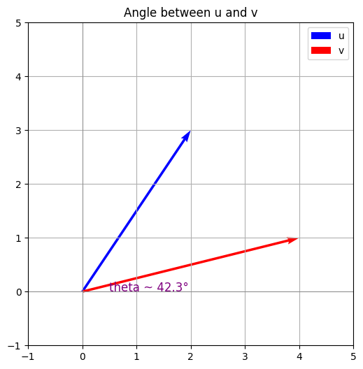

```python
# Let's visualize them on the same plot from the origin
plt.figure(figsize=(6,6))
plt.quiver(*origin, *u, color='blue', angles='xy', scale_units='xy', scale=1, label='u')
plt.quiver(*origin, *v, color='red', angles='xy', scale_units='xy', scale=1, label='v')

# Draw a faint line from tip of u to tip of v (just to illustrate the "triangle")
# plt.plot([u[0], v[0]], [u[1], v[1]], 'k--', alpha=0.3)

# We'll annotate the angle
midpoint = (u + v) / 4  # just a position somewhere in between for text
# plt.text(midpoint[0], midpoint[1], f"theta ~ {theta:.1f}°", color='purple', fontsize=12)
plt.text(0.5,0, f"theta ~ {theta_degrees:.1f}°", color='purple', fontsize=12)

plt.xlim(-1, 5)
plt.ylim(-1, 5)
plt.axhline(0, color='grey', linewidth=0.5)
plt.axvline(0, color='grey', linewidth=0.5)
plt.grid()
plt.title("Angle between u and v")
plt.legend()
plt.show()
```

### 3.5. Visualizing Vector Norms

**Concept**: The **norm** (or length) of a vector $\mathbf{u}$ is $\|\mathbf{u}\| = \sqrt{u_1^2 + u_2^2 + \cdots}$. In 2D, that’s the distance from $(0,0)$ to $(u_1,u_2)$.

```python
# Norm of u
norm_u = np.linalg.norm(u)
print("Norm of u:", norm_u)
```

[output not shown]

```python
# One way to visualize:
# We can draw a circle with radius = norm(u) around the origin to see how "long" u is.
circle = plt.Circle((0,0), norm_u, color='blue', fill=False, linestyle='--')

plt.figure(figsize=(6,6))
ax = plt.gca()  # get current axes

# Add the circle to axes
ax.add_patch(circle)

# Plot the vector u
plt.quiver(*origin, *u, color='red', angles='xy', scale_units='xy', scale=1, label='u')

plt.xlim(-1, 5)
plt.ylim(-1, 5)
plt.axhline(0, color='grey', linewidth=0.5)
plt.axvline(0, color='grey', linewidth=0.5)
plt.grid()
plt.title("Visualizing Norm of u")
plt.legend()
plt.show()
```

[output not shown]

### 3.6. Visualizing Cosine Similarity

**Concept**: The **cosine similarity** between two vectors is: $$\text{cosine\_similarity}(u, v) = \frac{u \cdot v}{\|u\|\|v\|} = \cos(\theta).$$

- Values range from -1 (opposite directions) to +1 (same direction).
- If $\mathbf{u}$ and $\mathbf{v}$ were in similar directions, you’d expect a **positive** and **close to 1** value.
- In many ML tasks (e.g., text embeddings), a higher cosine similarity means more similar vectors.

```python
cos_sim = np.dot(u, v) / (np.linalg.norm(u)*np.linalg.norm(v))
print("Cosine similarity between u and v =", cos_sim)
```

```
Cosine similarity between u and v = 0.7399400733959438
```

## 4. Summary & Next Steps

In this notebook, you have:

- Learned **what a vector is** (both algebraically and geometrically).
- Learned to differentiate between **scalar, vector, matrix**.
- Practiced **basic vector operations** (addition, subtraction, scalar multiplication).
- Learned the **dot product** and its **geometric meaning** (angle, projection).
- (Optional) **Visualized** vectors in 2D using `matplotlib`.

**Next**: We’ll move on to **Matrices** and their operations (addition, multiplication, special matrices) and see how they form the backbone of most data manipulations and transformations in data science.